# Using the Macleish Weather Data

Rose Goueth

12-16-2015

## Using the Macleish Weather Data

This R package can be used to process and analyze data from the MacLeish weather station. The following text will give you an outline of how to use the package.

To start using the package, you need to run the following code:

```r
require(macleish)
```

The data sets needed for this package already exists in the code. To explore the data, you can use the following tools:

head() will give you the first 6 readings within the data set. head(whatley) gives you the first six data points within the whatley data set. tail() will give you the last 6 readings of the data set. tail(whatley) will give you the last 6 readings, which in this context are also the most recent readings of the data collected.

```r
head(whately)
```

```
##         when record Temp_C_Avg WSpd_mps Wdir_deg RH_per_Avg Press_mb_Avg
## 1 2012-01-03  19638     -2.954     8.80    238.8      58.91          974
## 2 2012-01-03  19639     -2.950     8.80    238.8      58.22          974
## 3 2012-01-03  19640     -3.142     8.81    238.8      59.10          974
## 4 2012-01-03  19641     -3.188     8.80    238.8      59.34          974
## 5 2012-01-03  19642     -3.257     8.81    238.8      60.06          974
## 6 2012-01-03  19643     -3.268     8.81    238.8      59.94          974
##   SlrW_Avg Rain_mm_Tot
## 1        0           0
## 2        0           0
## 3        0           0
## 4        0           0
## 5        0           0
## 6        0           0
```

```r
tail(whately)
```

```
##              when record Temp_C_Avg WSpd_mps Wdir_deg RH_per_Avg
## 200928 2015-10-29  39737      19.52    3.358    226.4       95.2
## 200929 2015-10-29  39738      19.74    3.839    242.4       95.6
## 200930 2015-10-29  39739      17.97    3.619    262.1       98.1
## 200931 2015-10-29  39740      16.44    2.454    279.2      100.0
## 200932 2015-10-29  39741      16.26    2.565    263.5      100.0
## 200933 2015-10-29  39742      16.78    2.174    251.8       99.6
##        Press_mb_Avg SlrW_Avg Rain_mm_Tot
## 200928          967    293.5       0.000
## 200929          967    314.6       0.000
## 200930          968    100.9       0.254
## 200931          968    258.2       0.000
## 200932          968    254.6       0.000
## 200933          967    429.7       0.000
```

Analyzing the data:

Using plots can help you see your data visually. This is a good tool, especially if you want to find anomolies within the data.

For example, the total rainfall measurement may be off because someone bumped into the instrument, or because it could have shut off by itself. So graphing this column of data would be of best interest.

In order to find anomolies, you should plot the temperature against the total rainfall. Use the code below.

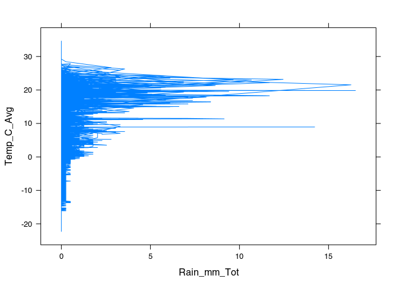

```r
require(mosaic)
xyplot(Temp_C_Avg ~ Rain_mm_Tot, data = whately, type = "l")
```

This graph shows you that for higher temperatures, there seems to be a lot of rainfall. I would double check your data values for 25 C (77 F) and see what happened at that temperature.

If you want to compute averages other than the 10 minute one, you can do so using simple math ! The example below shows you how to compute daily averages.

CAUTION: If you would rather use the daily data set, you may do so, but it will take you longer to make sure you are getting the right results. If you are a novice at R, I would adivse you to compute the daily averages with simple math.

Computing Daily averages

The following plot will show you how much rainfall you would have per day over the course of the data.

The “when” variable is used to plot the dates of each row of data. Since the data is updated very frequently, this plot will change on the rightmost side often throughtout the day.

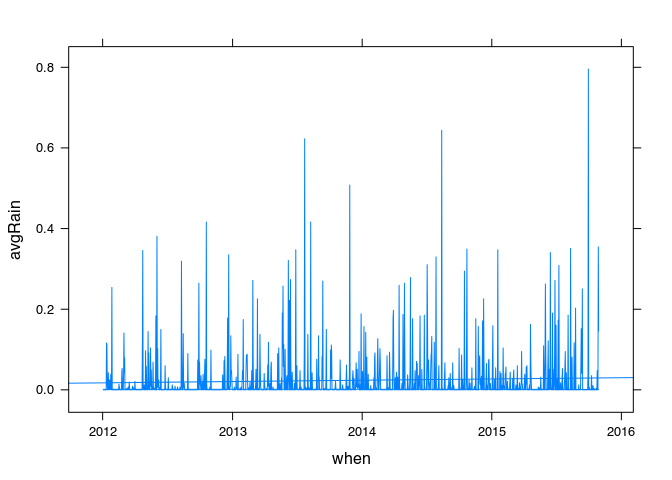

```r
daily <- whately %>%
  group_by(when) %>%
  summarize(N = n(), avgRain = mean(Rain_mm_Tot))
xyplot(avgRain ~ when, data = daily, type = c("l", "smooth", "r"))
```

To see the spread of your data, you can use a boxplot to see the minimum and maximum for your data.

The following plots the dates with the spreads:

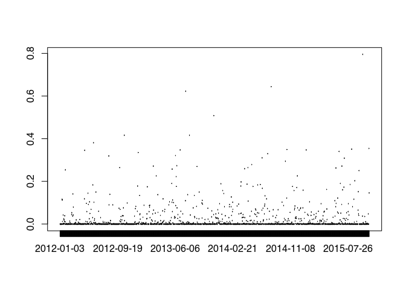

```r
daily <- whately %>%
  group_by(when) %>%
  summarize(N = n(), avgRain = mean(Rain_mm_Tot))
boxplot(avgRain ~ when, data = daily, type = c("l", "smooth", "r"))
```

These are some examples of you can explore and analyze data with this package.